# Web Dashboard

Flexdashboard dan Shinydashboard

Team Algoritma

Januari 26, 2022

```r
# install.packages("flexdashboard")
# install.packages("shiny")
# install.packages("DT") # optional, untuk memasukan tabel pada dashboard
```

# 1 Flexdashboard

1. We can setup the layout:
- `vertical_layout: fill/scroll`
- `orientation: column/rows`
- to make the panel 1 column/row, we can add `###` in new line
2. Template:
- Input your code of importing data until data preparation before the chunk of `Rows/Columns`
- We don’t need to print the data if we don’t want to show the data in our dashboard
- Input your code of making some plot and print the plot in the chunk after `Rows/Columns`
3. Consideration:
- Advantage: there’s template to make it easier
- Disanvantage: user can’t giving some input
4. Reference:
- Official documentation: https://rmarkdown.rstudio.com/flexdashboard/index.html
- Layouting Flexdashboard: https://rmarkdown.rstudio.com/flexdashboard/layouts.html
- Using Flexdashboard: https://rmarkdown.rstudio.com/flexdashboard/using.html
- Bootswatch Theme for Flexdashboard: https://bootswatch.com/

# 2 Shiny

Shiny is an open package from RStudio, which provides a web application framework to create interactive web applications (visualization) called “Shiny apps”. The ease of working with Shiny has what popularized it among R users. These web applications seamlessly display R objects (like plots, tables etc.) and can also be made live to allow access to anyone.

Shiny provides automatic reactive binding between inputs and outputs. It also provides extensive pre-built widgets which make it possible to build elegant and powerful applications with minimal effort.

**Structure of a basic shiny apps:**

- **global.R**: For setting-up the apps’ environment, e.g., libraries, import and initial cleaning dataset
- **ui.R**: User Interface (UI) for displaying input and output
- **server.R**: For processing user’s input and render it into output

One of many useful libraries that we can use is `shinydashboard`. We can use `shinydashboard` to create a dashboard apps for our users.

## 2.1 Basic **UI** Parts

The most common way is to add `sidebarMenu()` on the sidebar side and `tabItems()` on the body side:

- global.R:

```r
# library setup
library(shiny)
library(shinydashboard)
library(ggplot2)
library(plotly)
library(readr)
library(DT)
library(dplyr)
library(scales)
library(glue)
library(tidyverse)
options(scipen = 99)
```

- ui.R:

```r
header <- dashboardHeader()
sidebar <- dashboardSidebar()
body <- dashboardBody()

dashboardPage(header = header, sidebar = sidebar, body = body)
```

- server.R:

```r
function(input, output) {

}
```

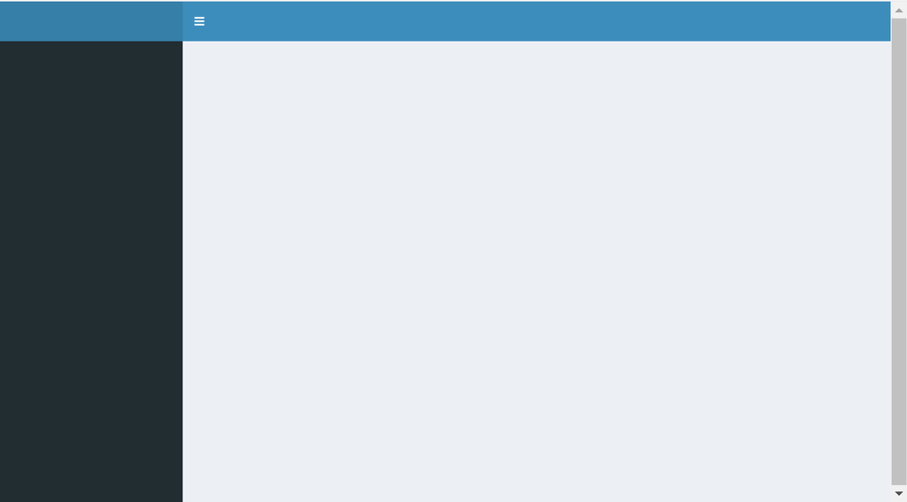

## 2.2 Sidebar Menu & Body

- global.R:

```r
# library setup
library(shiny)
library(shinydashboard)
library(ggplot2)
library(plotly)
library(readr)
library(DT)
library(dplyr)
library(scales)
library(glue)
library(tidyverse)
options(scipen = 99)
```

- ui.R:

```r
header <- dashboardHeader(title = "Avocado Price")
sidebar <- dashboardSidebar()
body <- dashboardBody()

dashboardPage(header = header, sidebar = sidebar, body = body)
```

- server.R:

```r
function(input, output) {

}
```

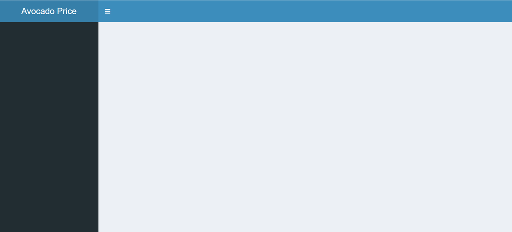

## 2.3 Set-up your First Input-Output Flow

A very common input-output flow can be outlined into some parts:

- **input:** use `*Input()` in **ui.R**, e.g. `selectInput()`
- **render:** use `output$outputName <- render*({ return(output_object) })` in **server.R**
- **output:** use `*Output("outputName")`in **ui.R**

In the real usage, you can change `*` with some basic grammar we frequently use.

For example:

- input: `selectInput()` for providing select input to users
- render: `output$outputID <- renderPlot({})` for rendering a static plot output or `output$outputID <- renderPlotly({})` for rendering a dinamic plot output
- output: `plotOutput("outputID")` for displaying a static plot output or `plotlyOutput("outputID")` for displaying a dinamic plot output

### 2.3.1 **1. Defining Input**

- global.R

```r
# library setup
library(shinydashboard)
library(readr)
library(dplyr)
library(ggplot2)
library(plotly)
library(shiny)
library(glue)
library(scales)
library(DT)

# import data
avo <- read_csv("../data_input/avocado.csv")

# data preparation
avo <- avo %>%
  mutate_if(is.character, as.factor)

#theme algoritma
theme_algoritma <- readRDS("../theme_algoritma.rds")
```

- ui.R

Notice that we now also add `fluidRow()` and `column()` to define the body layout of `Dashboard` tab and `Table` tab. Then, we add `selectInput` there.

```r
header <- dashboardHeader(title = "Avocado Price Dashboard")

sidebar <- dashboardSidebar(
    sidebarMenu(
        menuItem(text = "Dashboard", tabName = "dashboard", icon = icon("dashboard")),
        menuItem(text = "Region Price", tabName = "chart", icon = icon("chart-line")),
        menuItem(text = "Dataset", tabName = "data", icon = icon("table"))
    )
)
body <- dashboardBody(
    tabItems(
        tabItem(tabName = "dashboard",
                fluidRow(column(width = 12,
                                plotlyOutput(outputId = "plot1"))),
                br(),
                br(),
                # fluidRow(box()),
                fluidRow(column(width = 12,
                                plotlyOutput(outputId = "plot2"))
                         )
                ),
        tabItem(tabName = "chart",
                fluidRow(box(width = 3,
                             title = "Avocado type", status = "primary",
                             radioButtons(inputId = "type",
                                          label = "Select avocado type",
                                          choices = levels(avo$type)
                                          )
                             ),
                         column(width = 9,
                                plotlyOutput(outputId = "plot3"))
                         ),
                fluidRow(column(width = 12,
                                selectInput(inputId = "region",
                                            label = "Select the Region",
                                            choices = levels(avo$region)),
                                plotlyOutput(outputId = "plot4")))
                ),
        tabItem(tabName = "data",
                fluidRow(column(width = 12,
                                dataTableOutput(outputId = "data_avo"))))
    )
)


dashboardPage(header = header, sidebar = sidebar, body = body)
```

- server.R

```r
function(input, output){
    output$plot1 <- renderPlotly({
        p1 <- avo %>%
            ggplot(aes(x = AveragePrice)) +
            geom_histogram()+
            labs(title = "Distribusi Harga Alpukat", x = NULL, y = NULL) +
            scale_x_continuous(label = unit_format(prefix = "$ ", unit = "")) +
            theme_algoritma

        ggplotly(p1, tooltip = "x")
    })

    output$plot2 <- renderPlotly({

        p2 <- avo %>%
            filter(AveragePrice >= 1 & AveragePrice <= 1.5) %>%
            ggplot(aes(x = type, y = AveragePrice)) +
            geom_boxplot(aes(fill = type)) +
            labs(title = "Distribusi Harga Alpukat", subtitle = "pada Tipe") +
            theme_algoritma +
            theme(plot.subtitle = element_text(size = 12))

        ggplotly(p2)

    })

    output$plot3 <- renderPlotly({
        type_avo <- input$type

        # aggregasi
        min_price <- avo %>%
            filter(AveragePrice >= 0.95 & AveragePrice <= 1.6) %>%
            filter(type == type_avo) %>%
            group_by(region) %>%
            summarise(mean_price = mean(AveragePrice)) %>%
            ungroup() %>%
            arrange(mean_price) %>%
            head(10)

        # visualiasasi
        p3 <- min_price %>%
            ggplot(aes(y = reorder(region, desc(mean_price)), x = mean_price,
                       label = round(mean_price,2))) +
            geom_col(aes(fill = mean_price), show.legend = F) +
            geom_text(nudge_x = 0.1) +
            scale_fill_gradient(high = "#132B43", low = "#56B1F7") +
            ggtitle(label = paste("10 Region has Lowest", type_avo, "Avocado Price")) +
            labs(x = NULL, y = NULL) +
            theme_algoritma

        ggplotly(p3)
    })

    output$plot4 <- renderPlotly({

        type_avo <- input$type
        region_data <- input$region

        data <- avo %>%
            filter(type == type_avo) %>%
            filter(region == region_data)

       p4 <- data %>%
            ggplot(aes(x = Date, y = AveragePrice)) +
            geom_line(aes(group = region_data, col = region_data)) +
            geom_point(size = 0.01) +
            theme_algoritma

       ggplotly(p4)

    })

    output$data_avo <- renderDataTable({
        datatable(data = avo, options = list(scrollX =T, scrollY = T))
    })

}
```

### 2.3.2 **2. Rendering Output**

We’re now doing the rendering process on the server side:

- global.R

```r
# library setup
library(shinydashboard)
library(readr)
library(dplyr)
library(ggplot2)
library(plotly)
library(shiny)
library(glue)
library(scales)
library(DT)

# import data
avo <- read_csv("../data_input/avocado.csv")

# data preparation
avo <- avo %>%
  mutate_if(is.character, as.factor)

#theme algoritma
theme_algoritma <- readRDS("../theme_algoritma.rds")
```

- ui.R

```r
header <- dashboardHeader(title = "Avocado Price Dashboard")

sidebar <- dashboardSidebar(
    sidebarMenu(
        menuItem(text = "Dashboard", tabName = "dashboard", icon = icon("dashboard")),
        menuItem(text = "Region Price", tabName = "chart", icon = icon("chart-line")),
        menuItem(text = "Dataset", tabName = "data", icon = icon("table"))
    )
)
body <- dashboardBody(
    tabItems(
        tabItem(tabName = "dashboard",
                fluidRow(column(width = 12,
                                plotlyOutput(outputId = "plot1"))),
                br(),
                br(),
                # fluidRow(box()),
                fluidRow(column(width = 12,
                                plotlyOutput(outputId = "plot2"))
                         )
                ),
        tabItem(tabName = "chart",
                fluidRow(box(width = 3,
                             title = "Avocado type", status = "primary",
                             radioButtons(inputId = "type",
                                          label = "Select avocado type",
                                          choices = levels(avo$type)
                                          )
                             ),
                         column(width = 9,
                                plotlyOutput(outputId = "plot3"))
                         ),
                fluidRow(column(width = 12,
                                selectInput(inputId = "region",
                                            label = "Select the Region",
                                            choices = levels(avo$region)),
                                plotlyOutput(outputId = "plot4")))
                ),
        tabItem(tabName = "data",
                fluidRow(column(width = 12,
                                dataTableOutput(outputId = "data_avo"))))
    )
)


dashboardPage(header = header, sidebar = sidebar, body = body)
```

- **server.R**:

We’re now doing the rendering process on the server side

```r
function(input, output) {
    gap_worker <- reactive({

        year_option <- input$gap_workers

        gap <- workers %>%
            filter(year == year_option) %>%
            group_by(major_category) %>%
            summarise(Male = round(mean(workers_male/total_workers)*100,2),
                      Female = round(mean(percent_female),2)) %>%
            ungroup() %>%
            gather(key = "gender", value = "mean_workers", Male, Female)

        return(gap)
    })

    output$plot1 <- renderPlotly({
        data_input <- gap_worker()

        year_option <- input$gap_workers

        p1 <- ggplot(data_input, aes(x = major_category, y = mean_workers,
                                     text = paste(gender, ":", mean_workers))) +
            geom_col(position = "stack", aes(fill = gender))+
            coord_flip()+
            labs(x = NULL, y = NULL, title = paste("Men vs Female Workers in", year_option)) +
            theme_algoritma +
            theme(legend.position = "none")+
            scale_fill_manual(values = c("darkred", "grey0"))

        ggplotly(p1, tooltip = "text")
    })

}
```

### 2.3.3 **3. Displaying Output**

- global.R

```r
# library setup
library(shinydashboard)
library(readr)
library(dplyr)
library(ggplot2)
library(plotly)
library(shiny)
library(glue)
library(scales)
library(DT)

# import data
avo <- read_csv("../data_input/avocado.csv")

# data preparation
avo <- avo %>%
  mutate_if(is.character, as.factor)

#theme algoritma
theme_algoritma <- readRDS("../theme_algoritma.rds")
```

```r
header <- dashboardHeader(title = "Avocado Price Dashboard")

sidebar <- dashboardSidebar(
    sidebarMenu(
        menuItem(text = "Dashboard", tabName = "dashboard", icon = icon("dashboard")),
        menuItem(text = "Region Price", tabName = "chart", icon = icon("chart-line")),
        menuItem(text = "Dataset", tabName = "data", icon = icon("table"))
    )
)
body <- dashboardBody(
    tabItems(
        tabItem(tabName = "dashboard",
                fluidRow(column(width = 12,
                                plotlyOutput(outputId = "plot1"))),
                br(),
                br(),
                # fluidRow(box()),
                fluidRow(column(width = 12,
                                plotlyOutput(outputId = "plot2"))
                         )
                ),
        tabItem(tabName = "chart",
                fluidRow(box(width = 3,
                             title = "Avocado type", status = "primary",
                             radioButtons(inputId = "type",
                                          label = "Select avocado type",
                                          choices = levels(avo$type)
                                          )
                             ),
                         column(width = 9,
                                plotlyOutput(outputId = "plot3"))
                         ),
                fluidRow(column(width = 12,
                                selectInput(inputId = "region",
                                            label = "Select the Region",
                                            choices = levels(avo$region)),
                                plotlyOutput(outputId = "plot4")))
                ),
        tabItem(tabName = "data",
                fluidRow(column(width = 12,
                                dataTableOutput(outputId = "data_avo"))))
    )
)


dashboardPage(header = header, sidebar = sidebar, body = body)
```

- server.R

```r
function(input, output) {
    gap_worker <- reactive({

        year_option <- input$gap_workers

        gap <- workers %>%
            filter(year == year_option) %>%
            group_by(major_category) %>%
            summarise(Male = round(mean(workers_male/total_workers)*100,2),
                      Female = round(mean(percent_female),2)) %>%
            ungroup() %>%
            gather(key = "gender", value = "mean_workers", Male, Female)

        return(gap)
    })

    output$plot1 <- renderPlotly({
        data_input <- gap_worker()

        year_option <- input$gap_workers

        p1 <- ggplot(data_input, aes(x = major_category, y = mean_workers,
                                     text = paste(gender, ":", mean_workers))) +
            geom_col(position = "stack", aes(fill = gender))+
            coord_flip()+
            labs(x = NULL, y = NULL, title = paste("Men vs Female Workers in", year_option)) +
            theme_algoritma +
            theme(legend.position = "none")+
            scale_fill_manual(values = c("darkred", "grey0"))

        ggplotly(p1, tooltip = "text")
    })

}
```

### 2.3.4 **4. To add other elements (input/render/output), repeat above steps iteratively!**

- global.R

```r
# library setup
library(shinydashboard)
library(readr)
library(dplyr)
library(ggplot2)
library(plotly)
library(shiny)
library(glue)
library(scales)
library(DT)

# import data
avo <- read_csv("../data_input/avocado.csv")

# data preparation
avo <- avo %>%
  mutate_if(is.character, as.factor)

#theme algoritma
theme_algoritma <- readRDS("../theme_algoritma.rds")
```

```r
header <- dashboardHeader(title = "Avocado Price Dashboard")

sidebar <- dashboardSidebar(
    sidebarMenu(
        menuItem(text = "Dashboard", tabName = "dashboard", icon = icon("dashboard")),
        menuItem(text = "Region Price", tabName = "chart", icon = icon("chart-line")),
        menuItem(text = "Dataset", tabName = "data", icon = icon("table"))
    )
)
body <- dashboardBody(
    tabItems(
        tabItem(tabName = "dashboard",
                fluidRow(column(width = 12,
                                plotlyOutput(outputId = "plot1"))),
                br(),
                br(),
                # fluidRow(box()),
                fluidRow(column(width = 12,
                                plotlyOutput(outputId = "plot2"))
                         )
                ),
        tabItem(tabName = "chart",
                fluidRow(box(width = 3,
                             title = "Avocado type", status = "primary",
                             radioButtons(inputId = "type",
                                          label = "Select avocado type",
                                          choices = levels(avo$type)
                                          )
                             ),
                         column(width = 9,
                                plotlyOutput(outputId = "plot3"))
                         ),
                fluidRow(column(width = 12,
                                selectInput(inputId = "region",
                                            label = "Select the Region",
                                            choices = levels(avo$region)),
                                plotlyOutput(outputId = "plot4")))
                ),
        tabItem(tabName = "data",
                fluidRow(column(width = 12,
                                dataTableOutput(outputId = "data_avo"))))
    )
)


dashboardPage(header = header, sidebar = sidebar, body = body, skin = "red")
```

- server.R

[figure not shown]

```r
function(input, output) {
    gap_worker <- reactive({

        year_option <- input$gap_workers

        gap <- workers %>%
            filter(year == year_option) %>%
            group_by(major_category) %>%
            summarise(Male = round(mean(workers_male/total_workers)*100,2),
                      Female = round(mean(percent_female),2)) %>%
            ungroup() %>%
            gather(key = "gender", value = "mean_workers", Male, Female)

        return(gap)
    })

    output$plot1 <- renderPlotly({
        data_input <- gap_worker()

        year_option <- input$gap_workers

        p1 <- ggplot(data_input, aes(x = major_category, y = mean_workers,
                                     text = paste(gender, ":", mean_workers))) +
            geom_col(position = "stack", aes(fill = gender))+
            coord_flip()+
            labs(x = NULL, y = NULL, title = paste("Men vs Female Workers in", year_option)) +
            theme_algoritma +
            theme(legend.position = "none")+
            scale_fill_manual(values = c("darkred", "grey0"))

        ggplotly(p1, tooltip = "text")
    })

}
```

## 2.4 Customize your Dashboard Appearance:

You can also customize your dashboard appearance, such as adding icons, skins, etc.

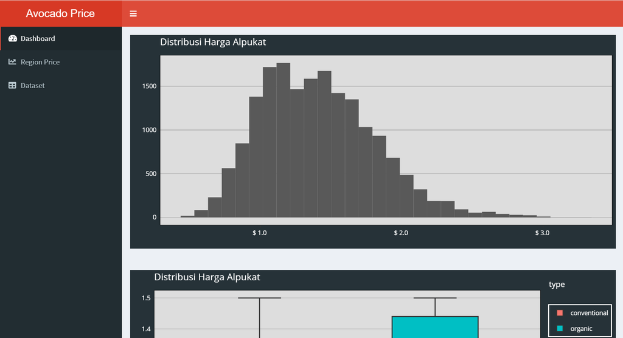

## 2.5 Resource Link

Please feel free to klik this link below to explore your shiny apps/shiny dashboard/flex dashboard

- [Get started with flex dashboard](https://rmarkdown.rstudio.com/flexdashboard/index.html)
- [Get started with shiny apps](https://shiny.rstudio.com/tutorial/)
- [Get started with shiny dashboard](https://rstudio.github.io/shinydashboard/)
- [Setting up shiny dashboard appearance](https://rstudio.github.io/shinydashboard/appearance)
- [Choose icon on sidebar menu](https://fontawesome.com/icons?from=io)
- [Customize inspirational shiny apps and shiny dashboard](http://www.showmeshiny.com/)
- [Shinyapps.io User Guide](https://docs.rstudio.com/shinyapps.io/index.html)